# Footnote: two ways of calling a testis library juvenile or adult

Author

Benjamin Fair

Published

August 27, 2026

## Why this page exists

The supplementary *UPF3A*/*UPF3B* panel compares juvenile against adult testis. There are two ways to decide which libraries are which, and the published panel and Fig 3c did not use the same one:

- **Landmark.** A library is adult once its within-species percent-rank developmental stage reaches the onset of meiosis in spermatogenesis, and juvenile between birth and that point. This is a rule evaluated per library.
- **Contrast table.** The two arms of the `Juvenile Testis v Adult Testis` row of `data/20260820_SupplementalTable_Contrasts.tsv`. These were first drawn by the landmark rule above and then corrected: the libraries sitting exactly on the landmark were inspected, and in some species they looked pre-meiotic and in others post-meiotic, so the boundary stage was assigned per species on that evidence. This is what every differential-splicing contrast in the paper was run on — including the one behind Fig 3c.

The published NMD panel used the landmark rule; Fig 3c used the contrast table. The main figure notebook now uses the contrast table for both, so the two panels rest on identical groups. This page keeps the comparison on the record: it plots the panel both ways, shows which libraries move, and shows what changes as a result.

Everything below is computed from the same shipped tables the main notebook reads. Nothing is copied from a previously rendered figure.

```python
import os

import numpy as np
import pandas as pd
import matplotlib
import matplotlib.pyplot as plt
import seaborn as sns
from scipy.stats import ttest_ind

matplotlib.rcParams.update({"pdf.fonttype": 42, "svg.fonttype": "none",
                            "font.family": "sans-serif",
                            "font.sans-serif": ["Helvetica", "Nimbus Sans", "DejaVu Sans"]})

OUT, DATA = "../output", "../data"
FIGDIR = "figures_footnote"
os.makedirs(FIGDIR, exist_ok=True)

SPECIES = ["Human", "Macaque", "Mouse", "Rat", "Rabbit", "Opossum", "Chicken"]
TISSUES = ["Brain", "Cerebellum", "Heart", "Kidney", "Liver", "Ovary", "Testis"]
GENE_ORDER = ["UPF3A", "UPF3B", "UPF3A/UPF3B"]
STAGE_COL = {"Juvenile": "#d95f02", "Adult": "#7570b3"}
SMALL_TXT, AXIS_TXT, LEG_TXT = 6.5, 9.0, 7.5
NEW_TESTIS_NAME = "Juvenile Testis v Adult Testis"
# the three developmental landmarks, and how they are drawn
MARK = {"Birth": ("#1b9e77", "Birth"),
        "Onset meiosis oogenesis": ("#e7298a", "Onset meiosis, oogenesis"),
        "OnsetMeiosis": ("#666666", "Onset meiosis, spermatogenesis")}


def savefig(fig, name):
    fig.savefig(os.path.join(FIGDIR, name), bbox_inches="tight")
    return os.path.join(FIGDIR, name)


def _signif(x, d):
    x = np.asarray(x, float)
    e = np.floor(np.log10(np.abs(np.where(x != 0, x, 1))))
    return np.round(x / 10.0 ** e, d - 1) * 10.0 ** e


def r_format_pval(vals, digits=1):
    """Emulate R's format.pval(x, digits) on a vector. Copied from the main figure
    notebook so the P labels here are formatted identically to the published panel.

    R splits at exponent -3, then within each subset uses a COMMON number of decimals -- set
    so the smallest element still shows `digits` significant figures, using the value AFTER
    rounding -- and picks fixed or scientific by whichever is not wider.
    """
    vals = np.asarray(vals, float)
    out = np.empty(len(vals), dtype=object)
    expo = np.floor(np.log10(np.where(vals > 0, vals, 1e-50)))
    for mask in (expo >= -3, expo < -3):
        if not mask.any():
            continue
        sub = vals[mask]
        dec = int(max(digits - 1 - np.floor(np.log10(_signif(sub, digits)))))
        out[mask] = ([f"%.{dec}f" % v for v in sub] if 2 + dec <=
                     max(len(f"%.{digits-1}e" % v) for v in sub)
                     else [f"%.{digits-1}e" % v for v in sub])
    return list(out)
```

## The libraries, and the two group assignments

`DataForReplotting_NMDFactorExpression.tsv.gz` holds one row per library per NMD gene, where `Delta` is log2 RPKM relative to the mean of the earliest stage sampled for that tissue. The ratio of interest is therefore `Delta(UPF3A) - Delta(UPF3B)`.

```python
nmd = pd.read_csv(f"{OUT}/DataForReplotting_NMDFactorExpression.tsv.gz", sep="\t")
markers = pd.read_csv(f"{OUT}/DataToPlot.DevelopmentalMarkers.tsv.gz", sep="\t")
contrasts = pd.read_csv(f"{DATA}/20260820_SupplementalTable_Contrasts.tsv", sep="\t")
mk = markers.set_index("Species")

# one row per library, every tissue, carrying the UPF3A/UPF3B ratio
sub = nmd[nmd["human.name"].isin(["UPF3A", "UPF3B"])]
w = (sub.pivot_table(index=["ID", "Species", "Tissue", "PercentRank_OrdinalStage"],
                     columns="human.name", values="Delta").reset_index()
        .dropna(subset=["UPF3A", "UPF3B"]))
w["UPF3A/UPF3B"] = w.UPF3A - w.UPF3B

# assignment A: developmental landmarks. A stage rule, so it applies to every tissue.
wl = w.merge(markers[["Species", "Birth", "OnsetMeiosis"]], on="Species", how="left")
wl["Stage"] = np.select(
    [(wl.PercentRank_OrdinalStage >= wl.Birth) & (wl.PercentRank_OrdinalStage < wl.OnsetMeiosis),
     wl.PercentRank_OrdinalStage >= wl.OnsetMeiosis], ["Juvenile", "Adult"], default=None)

# assignment B: the supplementary contrast table. Testis only, by construction.
rows = contrasts[contrasts.ContrastName == NEW_TESTIS_NAME]
recs = []
for _, x in rows.iterrows():
    for gi, col in [(1, "SamplesInGroup1"), (2, "SamplesInGroup2")]:
        recs += [{"ID": s, "Stage": "Juvenile" if gi == 1 else "Adult"}
                 for s in x[col].split(", ")]
ct = pd.DataFrame(recs)
absent = set(ct.ID) - set(w.ID)
assert not absent, f"contrast-table libraries missing from the expression table: {sorted(absent)}"
wc = w.merge(ct, on="ID", how="left")

pd.DataFrame({"libraries with both genes": [len(w)],
              "of those, testis": [(w.Tissue == "Testis").sum()],
              "in the contrast table": [len(ct)]})
```

|  | libraries with both genes | of those, testis | in the contrast table |
| --- | --- | --- | --- |
| 0 | 1695 | 165 | 93 |

Group sizes under the two assignments, testis only. The row totals are equal in every species — the same libraries are being partitioned, only the boundary differs.

```python
def sizes(df, label):
    return (df[(df.Tissue == "Testis") & df.Stage.notna()]
            .groupby(["Species", "Stage"]).size().unstack("Stage")
            .reindex(SPECIES)[["Juvenile", "Adult"]]
            .rename(columns=lambda c: f"{label}: {c}"))

tab = pd.concat([sizes(wl, "landmark"), sizes(wc, "contrast table")], axis=1)
tab["total"] = tab["landmark: Juvenile"] + tab["landmark: Adult"]
tab
```

| Stage Species | landmark: Juvenile | landmark: Adult | contrast table: Juvenile | contrast table: Adult | total |
| --- | --- | --- | --- | --- | --- |
| Human | 3 | 10 | 5 | 8 | 13 |
| Macaque | 12 | 9 | 15 | 6 | 21 |
| Mouse | 4 | 6 | 6 | 4 | 10 |
| Rat | 6 | 6 | 8 | 4 | 12 |
| Rabbit | 4 | 2 | 4 | 2 | 6 |
| Opossum | 14 | 8 | 16 | 6 | 22 |
| Chicken | 6 | 3 | 6 | 3 | 9 |

## The panel, drawn both ways

One helper, called twice. The only thing that differs between the two figures is the `Stage` column of the frame passed in.

```python
def nmd_panel(df, title, outname):
    """Reproduce the supplementary NMD panel from a frame carrying a Stage column."""
    d = df[(df.Tissue == "Testis") & df.Stage.notna()]
    lg = d.melt(id_vars=["ID", "Species", "Stage"], value_vars=GENE_ORDER,
                var_name="Gene", value_name="log2FC")
    jm = (lg[lg.Stage == "Juvenile"].groupby(["Gene", "Species"])["log2FC"]
          .mean().rename("mean_juv").reset_index())
    lg = lg.merge(jm, on=["Gene", "Species"])
    lg["rel"] = lg.log2FC - lg.mean_juv

    tt = {}
    for (sp, gene), s in lg.groupby(["Species", "Gene"]):
        tt[(sp, gene)] = ttest_ind(s.loc[s.Stage == "Juvenile", "log2FC"],
                                   s.loc[s.Stage == "Adult", "log2FC"],
                                   equal_var=True).pvalue

    rng = np.random.default_rng(1)
    fig, axes = plt.subplots(2, 4, figsize=(7.6, 4.4),
                             gridspec_kw={"wspace": 0.38, "hspace": 0.62})
    flat = axes.ravel()
    for ai, sp in enumerate(SPECIES):
        ax = flat[ai]
        s_sp = lg[lg.Species == sp]
        labs = dict(zip(GENE_ORDER, r_format_pval([tt[(sp, g)] for g in GENE_ORDER])))
        ax.axhline(0, color="black", lw=1.0, zorder=1)
        group_n = []
        for gi, gene in enumerate(GENE_ORDER):
            for st in ["Juvenile", "Adult"]:
                v = s_sp[(s_sp.Gene == gene) & (s_sp.Stage == st)].rel.values
                if not len(v):
                    continue
                xc = gi + (-0.19 if st == "Juvenile" else 0.19)
                group_n.append((xc, st, len(v)))
                bp = ax.boxplot([v], positions=[xc], widths=0.30, showfliers=False,
                                patch_artist=True, zorder=2)
                for el in ("boxes", "whiskers", "caps", "medians"):
                    for a in bp[el]:
                        a.set_color(STAGE_COL[st]); a.set_linewidth(0.9)
                bp["boxes"][0].set_facecolor("none")
                ax.scatter(xc + rng.uniform(-0.10, 0.10, len(v)), v, s=7,
                           color=STAGE_COL[st], lw=0, alpha=0.85, zorder=3)
        lo, hi = s_sp.rel.min(), s_sp.rel.max(); span = hi - lo
        ax.set_ylim(lo - span * 0.30, hi + span * 0.34)
        for xc, st, n in group_n:
            ax.text(xc, lo - span * 0.10, str(n), ha="center", va="top",
                    fontsize=SMALL_TXT, color=STAGE_COL[st])
        for gi, gene in enumerate(GENE_ORDER):
            ax.text(gi, hi + span * 0.12, f"P=\n{labs[gene]}", ha="center", va="bottom",
                    fontsize=SMALL_TXT)
        ax.set_xticks(range(len(GENE_ORDER)))
        ax.set_xticklabels(GENE_ORDER, rotation=45, ha="right", fontsize=SMALL_TXT)
        ax.set_xlim(-0.55, len(GENE_ORDER) - 0.45)
        ax.set_title(sp, fontsize=AXIS_TXT)
        ax.tick_params(axis="y", labelsize=SMALL_TXT)
        ax.grid(axis="y", color="0.92", lw=0.6, zorder=0)
        sns.despine(ax=ax)
    flat[-1].axis("off")
    fig.supylabel("log$_2$(Expression),\nrelative to mean juvenile expression",
                  fontsize=AXIS_TXT, x=-0.01, ma="center")
    fig.legend(handles=[plt.Line2D([], [], marker="s", ls="", markerfacecolor="none",
                                   markeredgecolor=STAGE_COL[s], markersize=6, label=s)
                        for s in ["Juvenile", "Adult"]],
               loc="upper center", bbox_to_anchor=(0.5, 1.06), ncol=2, frameon=False,
               fontsize=LEG_TXT, title="Testis stage", title_fontsize=LEG_TXT)
    fig.suptitle(title, fontsize=AXIS_TXT, y=1.14)
    savefig(fig, outname)
    return pd.DataFrame(
        [[r_format_pval([tt[(sp, g)]])[0] for g in GENE_ORDER] for sp in SPECIES],
        index=SPECIES, columns=GENE_ORDER)
```

### Landmark grouping, as published

```python
p_landmark = nmd_panel(wl, "Groups from developmental landmarks (as published)",
                       "NMD_UPF3_landmark.pdf")
p_landmark
```

|  | UPF3A | UPF3B | UPF3A/UPF3B |
| --- | --- | --- | --- |
| Human | 0.02 | 0.004 | 4e-04 |
| Macaque | 4e-04 | 0.9 | 9e-04 |
| Mouse | 0.03 | 0.002 | 0.01 |
| Rat | 0.1 | 0.3 | 0.2 |
| Rabbit | 0.2 | 0.2 | 0.5 |
| Opossum | 0.3 | 0.001 | 0.001 |
| Chicken | 2e-07 | 0.06 | 6e-07 |

(a) Juvenile and adult from the developmental landmarks. This is the published panel.

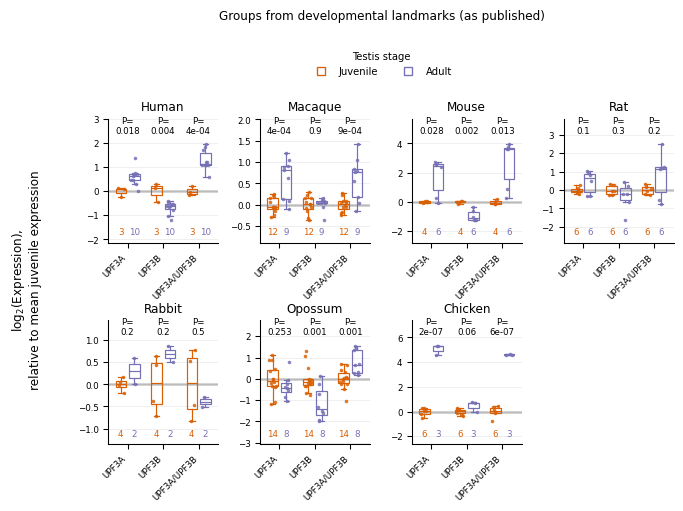

(b)

Figure 1

### Contrast-table grouping, as in Fig 3c

```python
p_contrast = nmd_panel(wc, "Groups from the supplementary contrast table (as in Fig 3c)",
                       "NMD_UPF3_contrasttable.pdf")
p_contrast
```

|  | UPF3A | UPF3B | UPF3A/UPF3B |
| --- | --- | --- | --- |
| Human | 0.003 | 0.05 | 0.001 |
| Macaque | 1e-09 | 0.9 | 2e-08 |
| Mouse | 4e-09 | 9e-05 | 1e-07 |
| Rat | 4e-05 | 0.02 | 2e-04 |
| Rabbit | 0.2 | 0.2 | 0.5 |
| Opossum | 0.04 | 1e-05 | 0.001 |
| Chicken | 2e-07 | 0.06 | 6e-07 |

(a) The same libraries, regrouped by the supplementary contrast table.

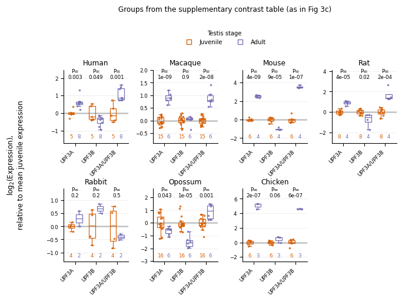

(b)

Figure 2

```python
pd.concat([p_landmark.add_suffix(" (landmark)"),
           p_contrast.add_suffix(" (contrast)")], axis=1)[
    [f"{g} ({k})" for g in GENE_ORDER for k in ("landmark", "contrast")]]
```

|  | UPF3A (landmark) | UPF3A (contrast) | UPF3B (landmark) | UPF3B (contrast) | UPF3A/UPF3B (landmark) | UPF3A/UPF3B (contrast) |
| --- | --- | --- | --- | --- | --- | --- |
| Human | 0.02 | 0.003 | 0.004 | 0.05 | 4e-04 | 0.001 |
| Macaque | 4e-04 | 1e-09 | 0.9 | 0.9 | 9e-04 | 2e-08 |
| Mouse | 0.03 | 4e-09 | 0.002 | 9e-05 | 0.01 | 1e-07 |
| Rat | 0.1 | 4e-05 | 0.3 | 0.02 | 0.2 | 2e-04 |
| Rabbit | 0.2 | 0.2 | 0.2 | 0.2 | 0.5 | 0.5 |
| Opossum | 0.3 | 0.04 | 0.001 | 1e-05 | 0.001 | 0.001 |
| Chicken | 2e-07 | 2e-07 | 0.06 | 0.06 | 6e-07 | 6e-07 |

## Where the two assignments disagree

Plotting each library against its ordinal stage makes the boundary visible. The three developmental landmarks are drawn as vertical lines; points are coloured by group assignment, grey where a library belongs to neither.

The landmark rule is a stage rule, so it colours every tissue.

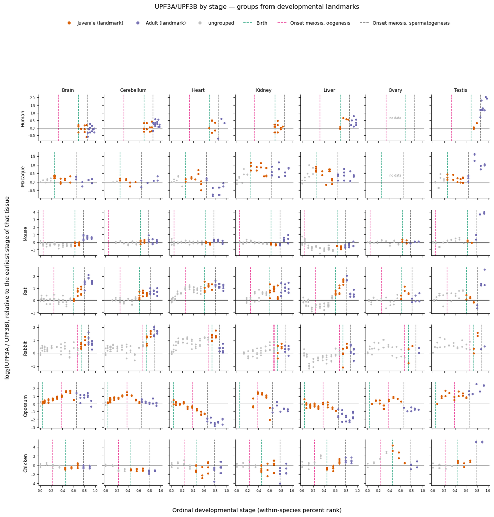

Figure 3: UPF3A/UPF3B against ordinal stage, coloured by the landmark grouping.

```python
def ordinal_grid(df, title, outname, grouping):
    fig, axes = plt.subplots(len(SPECIES), len(TISSUES), figsize=(15.5, 13.5),
                             sharex=True, sharey="row",
                             gridspec_kw={"wspace": 0.12, "hspace": 0.25})
    for ri, sp in enumerate(SPECIES):
        for ci, ti in enumerate(TISSUES):
            ax = axes[ri, ci]
            d = df[(df.Species == sp) & (df.Tissue == ti)]
            for col, (c, _) in MARK.items():
                v = mk.loc[sp, col]
                if pd.notna(v):
                    ax.axvline(v, color=c, lw=1.0, ls="--", zorder=1)
            un = d[d.Stage.isna()]
            ax.scatter(un.PercentRank_OrdinalStage, un["UPF3A/UPF3B"], s=11,
                       color="0.75", lw=0, zorder=2)
            for st in ["Juvenile", "Adult"]:
                g = d[d.Stage == st]
                ax.scatter(g.PercentRank_OrdinalStage, g["UPF3A/UPF3B"], s=16,
                           color=STAGE_COL[st], lw=0, zorder=3)
            ax.axhline(0, color="black", lw=0.6, zorder=1)
            ax.tick_params(labelsize=6)
            ax.set_xlim(-0.03, 1.03)
            if ri == 0:
                ax.set_title(ti, fontsize=9)
            if ci == 0:
                ax.set_ylabel(sp, fontsize=9)
            if not len(d):
                ax.text(0.5, 0.5, "no data", ha="center", va="center",
                        transform=ax.transAxes, fontsize=6, color="0.6")
            sns.despine(ax=ax)
    handles = ([plt.Line2D([], [], marker="o", ls="", color=STAGE_COL[s], markersize=5,
                           label=f"{s} ({grouping})") for s in ["Juvenile", "Adult"]]
               + [plt.Line2D([], [], marker="o", ls="", color="0.75", markersize=5,
                             label="ungrouped")]
               + [plt.Line2D([], [], color=c, ls="--", lw=1.2, label=lab)
                  for c, lab in MARK.values()])
    fig.legend(handles=handles, loc="upper center", bbox_to_anchor=(0.5, 1.035),
               ncol=6, frameon=False, fontsize=9)
    fig.supxlabel("Ordinal developmental stage (within-species percent rank)",
                  fontsize=11, y=0.055)
    fig.supylabel("log$_2$(UPF3A / UPF3B), relative to the earliest stage of that tissue",
                  fontsize=11, x=0.065, ma="center")
    fig.suptitle(title, fontsize=12, y=1.06)
    savefig(fig, outname)
    return None

ordinal_grid(wl, "UPF3A/UPF3B by stage — groups from developmental landmarks",
             "NMD_ordinal_landmark.pdf", "landmark")
```

The contrast table names testis libraries only, so every other panel is grey. The point of showing it is the testis column, which is directly comparable to the one above.

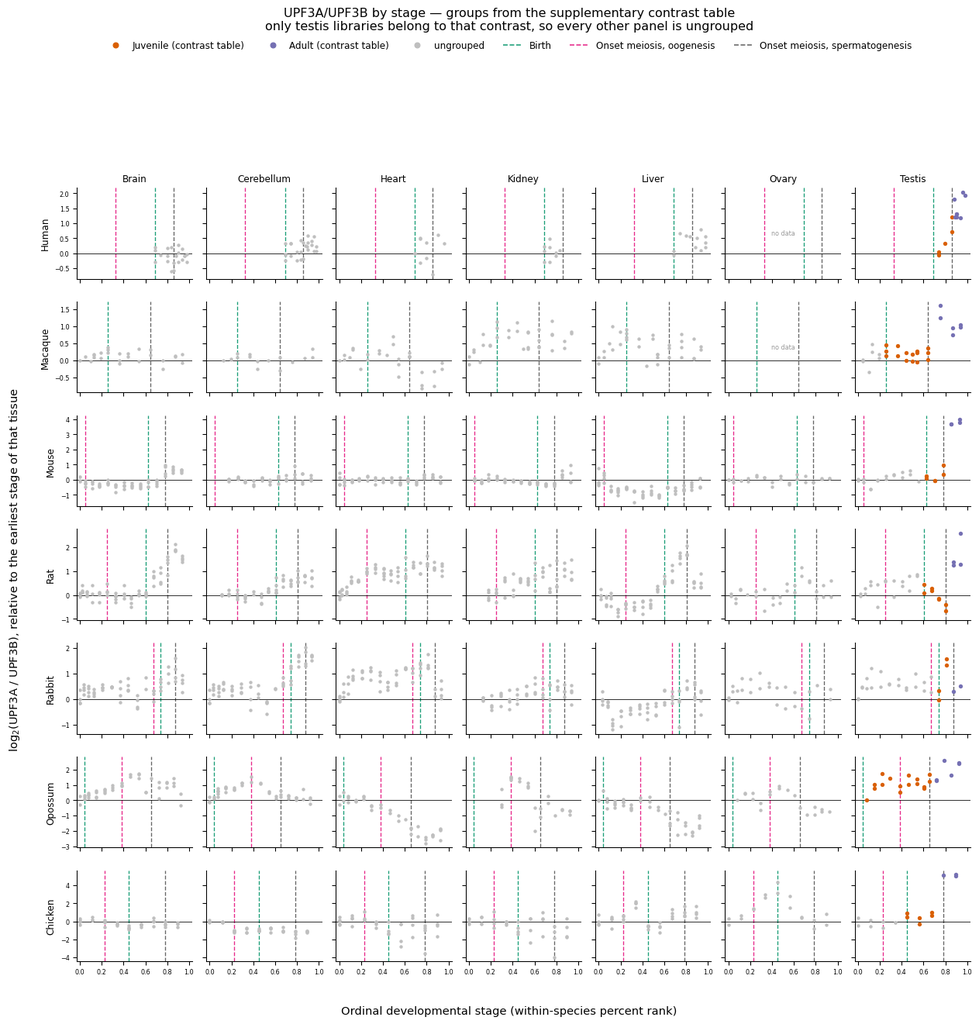

Figure 4: The same grid coloured by the contrast-table grouping.

```python
ordinal_grid(wc, "UPF3A/UPF3B by stage — groups from the supplementary contrast table\n"
                 "only testis libraries belong to that contrast, so every other panel is ungrouped",
             "NMD_ordinal_contrasttable.pdf", "contrast table")
```

Restricting to testis and stacking the two assignments per library isolates the difference. Black-outlined points are libraries the two groupings disagree about.

```python
tst = w[w.Tissue == "Testis"][["ID", "Species", "PercentRank_OrdinalStage", "UPF3A/UPF3B"]].copy()
tst = (tst.merge(wl[["ID", "Stage"]].rename(columns={"Stage": "landmark"}), on="ID")
          .merge(wc[["ID", "Stage"]].rename(columns={"Stage": "contrast"}), on="ID"))
tst["agree"] = tst.landmark.fillna("none") == tst.contrast.fillna("none")

fig, axes = plt.subplots(len(SPECIES), 1, figsize=(9.5, 11), sharex=True,
                         gridspec_kw={"hspace": 0.45})
for ax, sp in zip(axes, SPECIES):
    d = tst[tst.Species == sp].sort_values("PercentRank_OrdinalStage")
    for col, (c, _) in MARK.items():
        v = mk.loc[sp, col]
        if pd.notna(v):
            ax.axvline(v, color=c, lw=1.0, ls="--", zorder=1)
    for yi, key in enumerate(["contrast", "landmark"]):
        for _, r in d.iterrows():
            st = r[key]
            ax.scatter(r.PercentRank_OrdinalStage, yi, s=46,
                       color="0.85" if pd.isna(st) else STAGE_COL[st],
                       edgecolors="black" if not r.agree else "none", lw=1.1, zorder=3)
    ax.set_yticks([0, 1]); ax.set_yticklabels(["contrast table", "landmark"], fontsize=8)
    ax.set_ylim(-0.6, 1.6); ax.set_xlim(-0.03, 1.03)
    ax.set_title(f"{sp}   —   {len(d)} testis libraries, "
                 f"{(~d.agree).sum()} assigned differently", fontsize=9, loc="left")
    ax.tick_params(axis="x", labelsize=8)
    sns.despine(ax=ax, left=True)
handles = ([plt.Line2D([], [], marker="o", ls="", color=STAGE_COL[s], markersize=7, label=s)
            for s in ["Juvenile", "Adult"]]
           + [plt.Line2D([], [], marker="o", ls="", color="0.85", markersize=7, label="ungrouped"),
              plt.Line2D([], [], marker="o", ls="", markerfacecolor="white", markersize=7,
                         markeredgecolor="black", label="the two groupings disagree")]
           + [plt.Line2D([], [], color=c, ls="--", lw=1.2, label=lab) for c, lab in MARK.values()])
fig.legend(handles=handles, loc="upper center", bbox_to_anchor=(0.5, 1.03), ncol=4,
           frameon=False, fontsize=9)
fig.supxlabel("Ordinal developmental stage (within-species percent rank)", fontsize=11, y=0.045)
fig.suptitle("Which testis libraries the two groupings disagree about", fontsize=12, y=1.065)
savefig(fig, "NMD_testis_assignment_diff.pdf")
```

```
'figures_footnote/NMD_testis_assignment_diff.pdf'
```

(a) Which testis libraries move between groups.

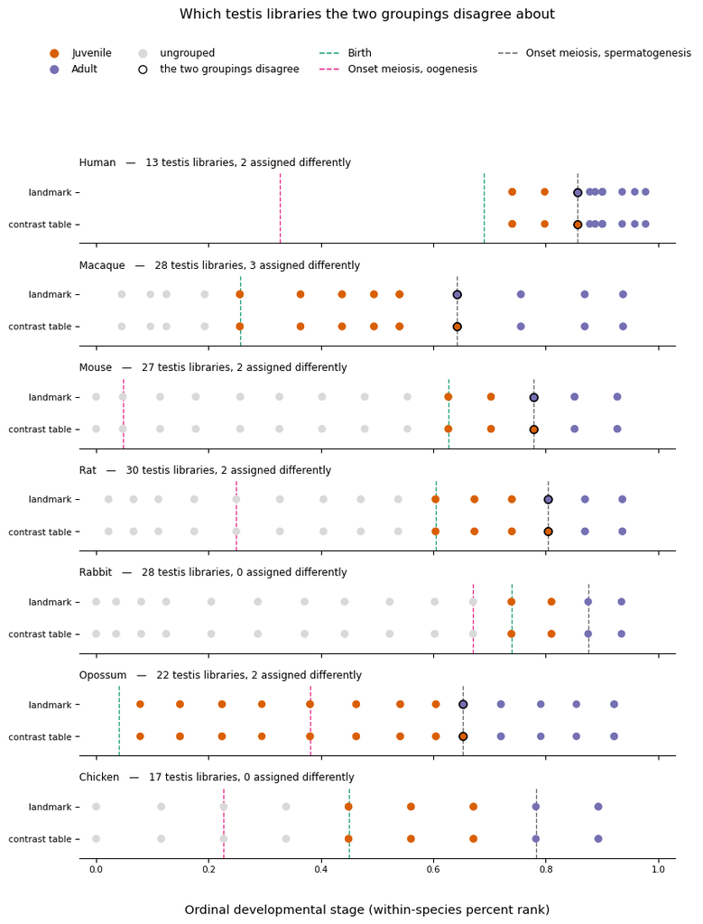

(b)

Figure 5

## What the difference actually is

Every library the two groupings disagree about sits **exactly on** the onset-of-meiosis landmark, and in every case the landmark rule calls it adult while the contrast table calls it juvenile.

```python
dis = tst[~tst.agree].copy()
dis["OnsetMeiosis"] = dis.Species.map(mk.OnsetMeiosis)
dis["stage - onset"] = dis.PercentRank_OrdinalStage - dis.OnsetMeiosis
dis[["Species", "ID", "PercentRank_OrdinalStage", "OnsetMeiosis", "stage - onset",
     "landmark", "contrast"]].sort_values(["Species", "PercentRank_OrdinalStage"])
```

|  | Species | ID | PercentRank_OrdinalStage | OnsetMeiosis | stage - onset | landmark | contrast |
| --- | --- | --- | --- | --- | --- | --- | --- |
| 17 | Human | Human_Testis_14ypb_5561 | 0.855769 | 0.855769 | 0.0 | Adult | Juvenile |
| 18 | Human | Human_Testis_14ypb_5564 | 0.855769 | 0.855769 | 0.0 | Adult | Juvenile |
| 50 | Macaque | Macaque_Testis_3ypb_5443 | 0.642045 | 0.642045 | 0.0 | Adult | Juvenile |
| 51 | Macaque | Macaque_Testis_3ypb_6080 | 0.642045 | 0.642045 | 0.0 | Adult | Juvenile |
| 52 | Macaque | Macaque_Testis_3ypb_6082 | 0.642045 | 0.642045 | 0.0 | Adult | Juvenile |
| 77 | Mouse | Mouse_Testis_2wpb_1879 | 0.778481 | 0.778481 | 0.0 | Adult | Juvenile |
| 78 | Mouse | Mouse_Testis_2wpb_1883 | 0.778481 | 0.778481 | 0.0 | Adult | Juvenile |
| 101 | Opossum | Opossum_Testis_60dpb_4661 | 0.652985 | 0.652985 | 0.0 | Adult | Juvenile |
| 102 | Opossum | Opossum_Testis_60dpb_4731 | 0.652985 | 0.652985 | 0.0 | Adult | Juvenile |
| 159 | Rat | Rat_Testis_2wpb_2344 | 0.803324 | 0.803324 | 0.0 | Adult | Juvenile |
| 160 | Rat | Rat_Testis_2wpb_2347 | 0.803324 | 0.803324 | 0.0 | Adult | Juvenile |

### Why the disagreement sits exactly there

This is not a coincidence, and the contrast table is not an independent grouping. The contrast groups were originally drawn *by* the landmark rule, from the same ordinal stage table, and were consistent with it. The stage that falls exactly on the landmark is the ambiguous one: looking at the libraries sitting right on that boundary, some species’ borderline samples looked pre-meiotic and others looked post-meiotic. The contrast table records that per-species judgement; the mechanical rule, which resolves the tie one way for everybody (`PercentRank >= OnsetMeiosis → Adult`), cannot.

So the contrast table is the landmark rule plus a hand adjudication of the single boundary stage, and the disagreements are exactly the libraries that adjudication moved. That also predicts what we see for rabbit and chicken: they have a library at exactly the onset stage too, and there the borderline sample was judged post-meiotic, so the table agrees with the rule and the group sizes already matched.

```python
on = tst.copy()
on["OnsetMeiosis"] = on.Species.map(mk.OnsetMeiosis)
on = on[np.isclose(on.PercentRank_OrdinalStage, on.OnsetMeiosis)]
(on.groupby(["Species", "landmark", "contrast"], dropna=False).size()
   .rename("libraries").reset_index().set_index("Species").reindex(SPECIES))
```

| Species | landmark | contrast | libraries |
| --- | --- | --- | --- |
| Human | Adult | Juvenile | 2 |
| Macaque | Adult | Juvenile | 3 |
| Mouse | Adult | Juvenile | 2 |
| Rat | Adult | Juvenile | 2 |
| Rabbit | Adult | Adult | 1 |
| Opossum | Adult | Juvenile | 2 |
| Chicken | Adult | Adult | 1 |

The contrast table is therefore the grouping to use: it carries information the stage table does not, namely what the borderline libraries actually look like. It is also the grouping every differential-splicing contrast in the paper was run on.

```python
man = sorted(f for f in os.listdir(FIGDIR) if f.endswith(".pdf"))
pd.DataFrame({"panel": man,
              "KB": [round(os.path.getsize(os.path.join(FIGDIR, f)) / 1024, 1) for f in man]})
```

|  | panel | KB |
| --- | --- | --- |
| 0 | NMD_UPF3_contrasttable.pdf | 42.0 |
| 1 | NMD_UPF3_landmark.pdf | 41.7 |
| 2 | NMD_ordinal_contrasttable.pdf | 62.3 |
| 3 | NMD_ordinal_landmark.pdf | 82.9 |
| 4 | NMD_testis_assignment_diff.pdf | 38.8 |